# Continuous_Variable_Analysis

Paige Duffin

11/7/2019

# Exploratory Analysis

## Preparing Workspace

Load necessary packages

```r
library(caret) # Classification and Regression Training
```

```r
library(corrplot)
library(dplyr) # A Grammar of Data Manipulations
library(forcats) # Tools for Working with Categorical Variables (Factors)
library(gdata) # Various R Programming Tools for Data Manipulation
library(ggplot2) # Create Elegant Data Visualizations Using the Grammar of Graphics
library(ggrepel) # Automatically Position Non-Overlapping Text Labels with ‘ggplot2’
library(ggridges) # Ridgeline Plots in ‘ggplot2’
library(ggthemes) # Extra Themes, Scales, and Geoms for ‘ggplot2’
library(gmodels) # Various R Programming Tools for Model Fitting
library(grid) # The Grid Graphics Package
library(gridExtra)
library(knitr) # A General-Purpose Package for Dynamic Report Generation in R
library(lmtest) # Testing Linear Regression Models
library(plyr) # Tools for Splitting, Applying and Combining Data
library(purrr) # Functional Programming Tools
library(readr) # Read Rectangular Text Data
library(rpart)
library(rattle)
library(scales) # Scale Functions for Visualization
library(shiny) # Web Application Framework for R
library(skimr) # Compact and Flexible Summaries of Data
library(stringr) # Simple, Consistent Wrappers for Common String Operations
library(tibble) # Simple Data Frames
library(tidyr) # Easily Tidy Data with ‘spread()’ and ‘gather()’ Functions
library(tidyverse) # Install and Load ‘Tidyverse’ Packages
library(usmap)
library(rworldmap)
library(ggmap)
library(maps)
library(mapdata)
library(cowplot)
library("googleway")
library("ggspatial")
library("rnaturalearth")
library("rnaturalearthdata")
theme_set(theme_bw())
library("sf")
library(gridExtra)
titletheme_small <- theme(plot.title = element_text(size=9,vjust=0.1))
titletheme <- theme(plot.title = element_text(size=12,vjust=0.1))
library("viridis")
world <- ne_countries(scale = "medium", returnclass = "sf") #for mapping
#install.packages("tableone")
library("tableone")
```

Creating dfs of color schemes I may use

```r
mycolors <- c("brown1","lightseagreen","goldenrod1","slateblue")
species_colors <- c("royalblue","salmon","darkmagenta")
pisaster_colors <- c("thistle1","plum","orchid3","darkmagenta")
RMSE_colors <- c("slategray1","steelblue3","thistle2","plum3")
pisaster_size_colors2 <- c("lightsteelblue1","skyblue","slateblue3","slateblue4")
pisaster_size_colors <- c("lavender","mediumpurple3","slateblue3","slateblue4")
```

Load cleaned data

```r
#clean_data <- readRDS("./data/processed_data/processeddata.rds")
clean_data <- readRDS("../../data/processed_data/processeddata.rds")
skim(clean_data)
```

```
## Skim summary statistics
##  n obs: 13165
##  n variables: 23
##
## ── Variable type:factor ───────────────────────────────────────────────────────────────────────────────────────────
##               variable missing complete     n n_unique
##              bioregion       0    13165 13165        6
##              georegion       0    13165 13165        9
##             group_code       0    13165 13165        9
##  group_code_UCSC_other       0    13165 13165        2
##                 island       0    13165 13165        6
##     marine_season_code       0    13165 13165       57
##       marine_site_name       0    13165 13165       77
##            method_code       0    13165 13165        4
##   method_code_IP_other       0    13165 13165        2
##             mpa_region       0    13165 13165        6
##            season_name       0    13165 13165        4
##              site_code       0    13165 13165       77
##           species_code       0    13165 13165        3
##                  state       0    13165 13165        4
##                                              top_counts ordered
##   San: 5608, Oly: 4138, Gov: 2366, Sal: 652               FALSE
##   CA : 5382, CA : 2592, CA : 1660, OR: 1386               FALSE
##    UCS: 9657, UCL: 2032, PBN: 400, SSS: 366               FALSE
##                 UCS: 9657, Oth: 3508, NA: 0               FALSE
##    Mai: 12364, Bar: 279, Sad: 250, Hat: 150               FALSE
##      SU1: 440, SU1: 403, SU1: 392, FA1: 376               FALSE
##      Mil: 524, Sco: 513, Sti: 472, End: 468               FALSE
##      IP: 12012, BT2: 782, GSE: 336, TS3: 35               FALSE
##                 IP: 12012, Oth: 1153, NA: 0               FALSE
##  Cen: 5382, Sou: 2627, NUL: 1932, Nor: 1660               FALSE
##    Sum: 4552, Fal: 4489, Spr: 4112, Win: 12               FALSE
##      MCR: 524, SCT: 513, SWC: 472, END: 468               FALSE
##                                           P.o: 11416, K   FALSE
##       CA: 10548, OR: 1386, WA: 865, AK: 366               FALSE
##
## ── Variable type:integer ──────────────────────────────────────────────────────────────────────────────────────────
##              variable missing complete     n    mean      sd   p0  p25
##  marine_common_season       0    13165 13165  116.82   19.23   78  101
##    marine_common_year       0    13165 13165 2009.7     4.81 2000 2006
##     marine_sort_order       0    13165 13165 5566.24 1125.15 1720 5020
##       season_sequence       0    13165 13165    2.03    0.81    1    1
##              size_bin       0    13165 13165   82.44   42.2     5   50
##       size_sort_order       0    13165 13165    9.57    4.15    1    6
##                 total       0    13165 13165    9.92   16.43    1    2
##   p50  p75 p100     hist
##   118  131  152 ▅▅▆▇▇▇▇▅
##  2010 2013 2018 ▃▅▅▇▇▆▆▆
##  6090 6370 7650 ▁▁▁▂▃▃▇▁
##     2    3    4 ▇▁▇▁▁▇▁▁
##    80  110  320 ▅▇▇▃▁▁▁▁
##    10   12   33 ▅▇▇▃▁▁▁▁
##     4   11  360 ▇▁▁▁▁▁▁▁
##
## ── Variable type:numeric ──────────────────────────────────────────────────────────────────────────────────────────
##   variable missing complete     n    mean   sd      p0     p25     p50
##   latitude       0    13165 13165   38.67 5.2    32.87   34.73   36.62
##  longitude       0    13165 13165 -122.25 2.86 -135.38 -123.98 -121.94
##      p75    p100     hist
##    41.65   57.05 ▇▆▃▂▁▁▁▁
##  -120.62 -117.25 ▁▁▁▁▅▇▆▃
```

## Data Tidying/Visualization

Outcome of interest is `total`, but really just for Pisaster.

```r
P.ochra_clean_data <- filter(clean_data, clean_data$species_code == "P.ochraceus")
#names(P.ochra_clean_data)
P.ochra_numer_data <- P.ochra_clean_data %>% dplyr::select(total, marine_common_season, marine_common_year, marine_sort_order, season_sequence, size_bin, size_sort_order, latitude, longitude)

P.ochra_numer_data <- P.ochra_numer_data %>% mutate(season_year = marine_common_season) %>% dplyr::select(-marine_common_season)

P.ochra_numer_data <- P.ochra_numer_data %>% mutate(year = marine_common_year) %>% dplyr::select(-marine_common_year)

P.ochra_numer_data <- P.ochra_numer_data %>% mutate(season_num = season_sequence) %>% dplyr::select(-season_sequence)

P.ochra_numer_data <- P.ochra_numer_data %>% mutate(size_sort = size_sort_order) %>% dplyr::select(-size_sort_order)

P.ochra_numer_data <- P.ochra_numer_data %>% mutate(order_site = marine_sort_order) %>% dplyr::select(-marine_sort_order)
```

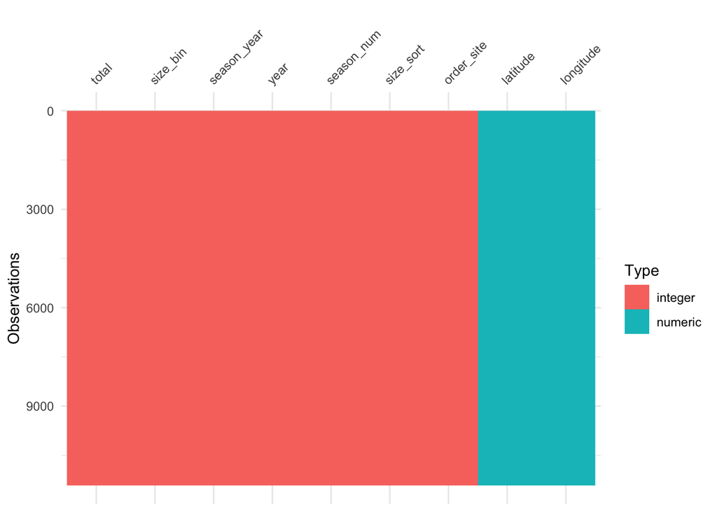

```r
visdat::vis_dat(P.ochra_numer_data)
```

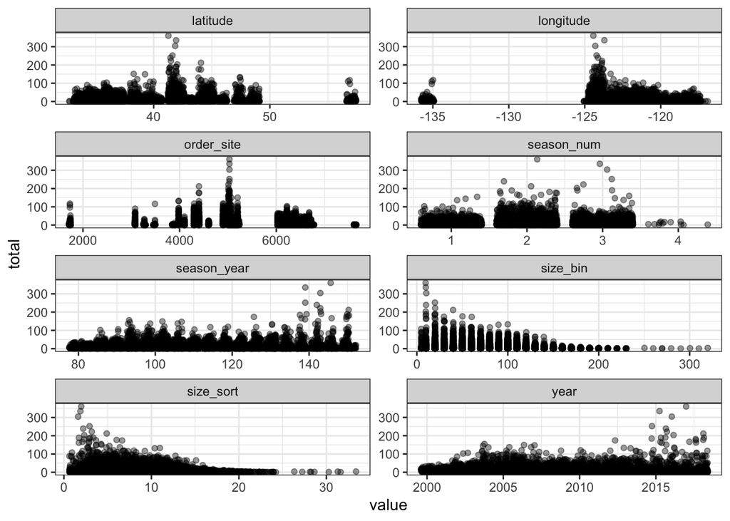

```r
myPalette <- colorRampPalette(viridis_pal(begin = 0, end = 1,option = "plasma")(8),)
plasma_continuous <- scale_colour_gradientn(colours = myPalette(91328))


p1 <- P.ochra_numer_data %>% select_if(is.numeric) %>% gather(-total, key = "var", value = "value") %>%
            ggplot() + geom_jitter(aes(x = value, y=total), alpha = 0.4, width = 0.4) +
            facet_wrap(~ var, scales = "free",nrow=4) + theme_bw()
print(p1)
```

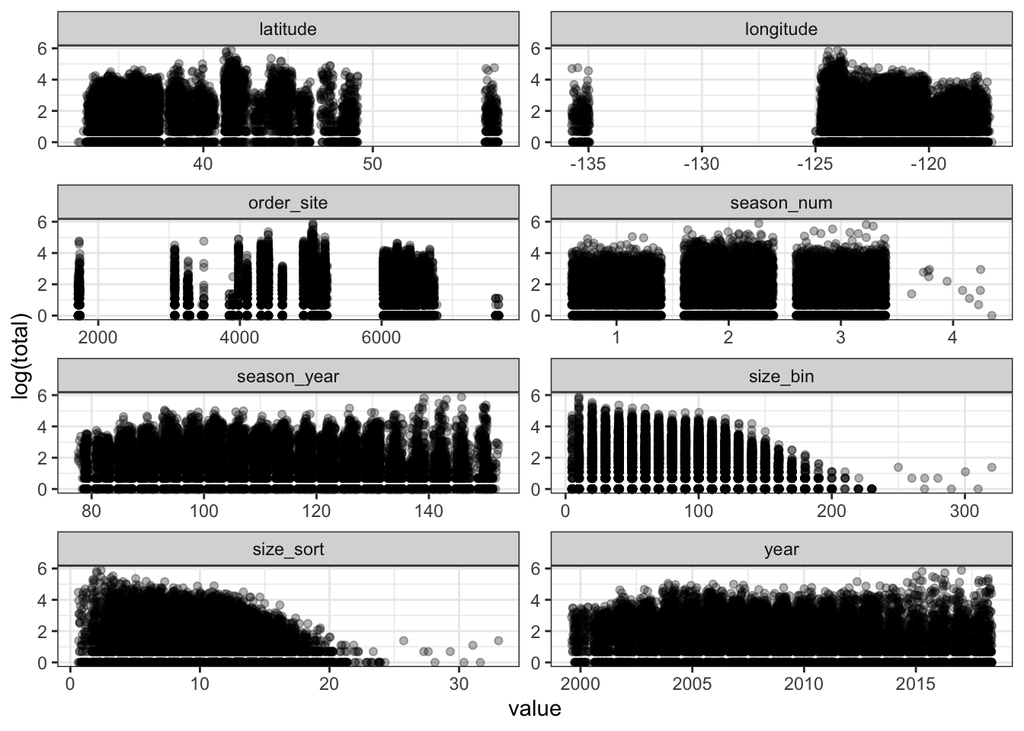

```r
p1log <- P.ochra_numer_data %>% select_if(is.numeric) %>% gather(-total, key = "var", value = "value") %>%
            ggplot() + geom_jitter(aes(x = value, y=log(total)), alpha = 0.3, width = 0.4)+
            facet_wrap(~ var, scales = "free",nrow=4) + theme_bw()
print(p1log)
```

```r
ggsave(filename = "../../results/Continuous_Outcome_Modeling_results/1.count_vs_numerical.png",plot = p1log, width = 5, height = 4)
```

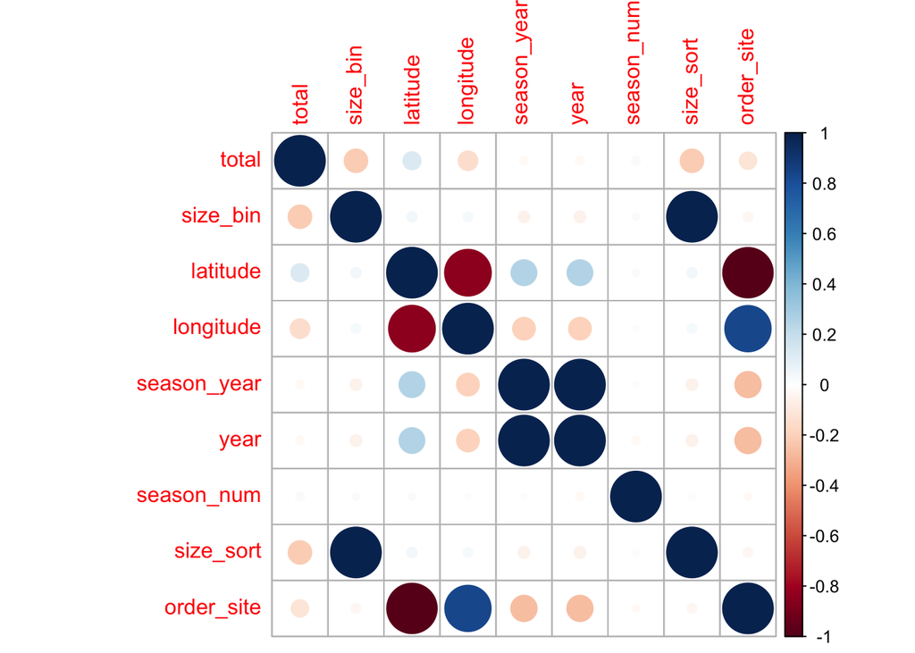

```r
P.ochra_numer_data_corr <- P.ochra_numer_data %>% select_if(is.numeric) %>% cor()
P.ochra_numer_data_corr <- corrplot::corrplot(P.ochra_numer_data_corr)
```

Okay, so a few of these are highly correlated, and for good reason. The only one I can really think to justify getting rid of one of the two correlated variables for is the `size_sort`/`size_bin`. `size_sort` is as informative as `size_bin`, and more, so I’ll get rid of `size_bin`

```r
P.ochra_numer_data <- P.ochra_numer_data %>% dplyr::select(-size_bin)
```

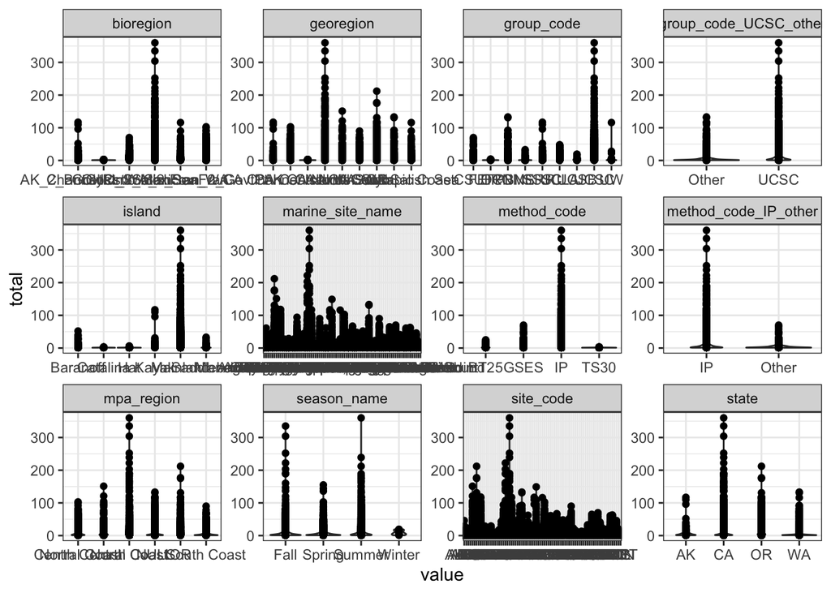

```r
P.ochra_categ_data <- P.ochra_clean_data %>% select_if(is.factor)
P.ochra_categ_data$total <- P.ochra_clean_data$total
P.ochra_categ_data <- P.ochra_categ_data %>% dplyr::select(-species_code)
p2 <- P.ochra_categ_data %>% gather(-total, -marine_season_code, key = "var", value = "value") %>% ggplot() + geom_violin(aes(x = value, y=total)) + geom_point(aes(x = value, y=total)) + facet_wrap(~ var, scales = "free") + theme_bw()
print(p2)
```

```r
P.ochra_categ_data <- P.ochra_clean_data %>% select_if(is.factor)
P.ochra_categ_data$total <- P.ochra_clean_data$total
P.ochra_categ_data <- P.ochra_categ_data %>% dplyr::select(-species_code)
p2log <- P.ochra_categ_data %>% gather(-total, -marine_season_code, -marine_site_name, -group_code_UCSC_other, -method_code_IP_other, key = "var", value = "value") %>% ggplot() + geom_violin(aes(x = value, y=log(total), col=value)) + geom_point(aes(x = value, y=log(total), col=value)) + facet_wrap(~ var, scales = "free",nrow=3) + theme_bw() + theme(legend.position = "none") #+
  scale_color_manual(values=pisaster_size_colors)
```

[output not shown]

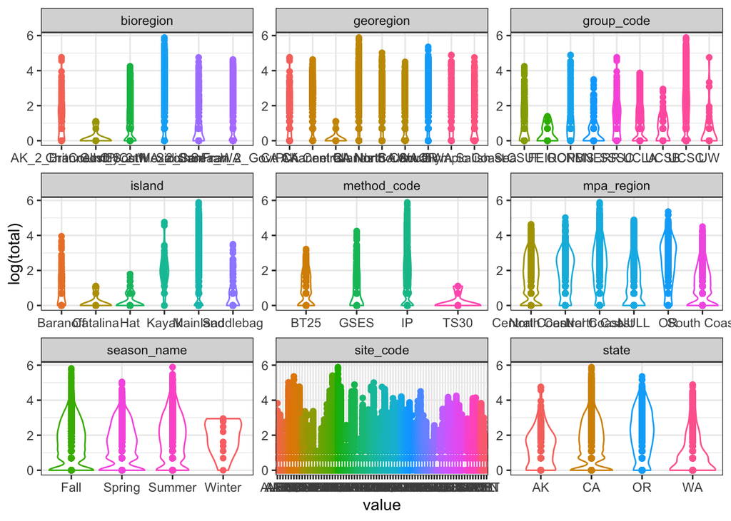

```r
print(p2log)
```

```r
ggsave(filename = "../../results/Continuous_Outcome_Modeling_results/2.count_vs_categorical.png",plot = p2log, width = 5, height = 4)
```

## Model Fitting

### Data Splitting

```r
set.seed(123)
trainset <- caret::createDataPartition(y = P.ochra_numer_data$total, p = 0.7, list = FALSE)
data_train = P.ochra_numer_data[trainset,] #extract observations/rows for training, assign to new variable
data_test = P.ochra_numer_data[-trainset,] #do the same for the test set
```

### Null Model

```r
outcome = data_train$total
Nobs=nrow(data_train)
base_RMSE <- sqrt(sum((outcome-mean(outcome))^2)/Nobs)
print(sprintf('RMSE of baseline model is %f',base_RMSE))
```

```
## [1] "RMSE of baseline model is 17.132094"
```

### Single Predictor Models

```r
#There is probably a nicer tidyverse way of doing this. I just couldn't think of it, so did it this way.
set.seed(1111) #makes each code block reproducible
fitControl <- trainControl(method="repeatedcv",number=5,repeats=5) #setting CV method for caret
Npred <- ncol(data_train)-1 # number of predictors
resultmat <- data.frame(Variable = names(data_train)[-1], RMSE = rep(0,Npred)) #store values for RMSE for each variable
for (n in 2:ncol(data_train)) #loop over each predictor. For this to work, outcome must be in 1st column
{
  fit1 <- train( as.formula(paste("total ~",names(data_train)[n])) , data = data_train, method = "lm", trControl = fitControl)
 resultmat[n-1,2]= fit1$results$RMSE
}
```

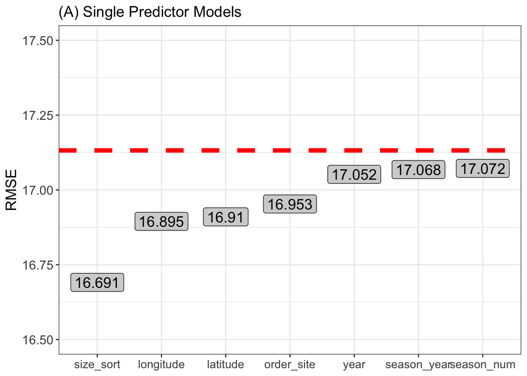

```r
resultmat_ordered <- resultmat %>%
  mutate(Variable = factor(Variable, levels = c("size_sort","longitude","latitude","order_site","year","season_year","season_num"))) %>%
  arrange(Variable)
resultmat_ordered$RMSE <- round(resultmat_ordered$RMSE,3)

Single_Predictor_RMSE <- resultmat_ordered %>% ggplot(aes(x = Variable, y=RMSE, label =RMSE)) + ylim(16.5,17.5) + geom_hline(yintercept=base_RMSE,color='red', size=2,linetype="dashed") +   geom_label(stat='identity',color="black", size=5, face="bold",fill="lightgrey") + theme(title = element_text(size=12), axis.title.y = element_text(size=14),axis.title.x = element_blank(),axis.text.y = element_text(size=12),axis.text.x = element_text(size=11)) + ggtitle("(A) Single Predictor Models")
Single_Predictor_RMSE
```

```r
#ggsave(filename = "../../results/Continuous_Outcome_Modeling_results/3.Single_Predictor_RMSE.png",plot = Single_Predictor_RMSE, width = 5, height = 4)
```

### Multiple Predictor Models

```r
set.seed(1111) #makes each code block reproducible
fitControl <- trainControl(method="repeatedcv",number=5,repeats=5)
fit2 <- train(total ~ ., data = data_train, method = "lm", trControl = fitControl)
```

[output not shown]

[output cut: 19 more lines]

[output not shown]

```r
fit3 <- train(total ~ ., data = data_train, method = "knn", trControl = fitControl)
fit4 <- train(total ~ ., data = data_train, method = "earth", trControl = fitControl)
print(sprintf('RMSE of lm/knn/mars model %f/%f/%f', fit2$results$RMSE, min(fit3$results$RMSE), min(fit4$results$RMSE) ))
```

```
## [1] "RMSE of lm/knn/mars model 16.419378/12.154684/15.757559"
```

```r
library(knitr)
#install.packages("kableExtra")
library(kableExtra)
Model <- c("knn","mars","lm")
RMSE <- c(12.154,15.758,16.419)
Multipred_df <- data.frame(Model,RMSE)
#Multipred_df$RMSE <- as.(Multipred_df$RMSE)
Multipred_df
```

```
##   Model   RMSE
## 1   knn 12.154
## 2  mars 15.758
## 3    lm 16.419
```

```r
#Multipred_table <- Multipred_df %>%
 # kable() %>%
 # kable_styling(bootstrap_options = c("striped", "hover"),full_width = F)
#Multipred_table

#Multipred_table %>% save_kable("../../results/Continuous_Outcome_Modeling_results/4.Single_Predictor_RMSE.png")
```

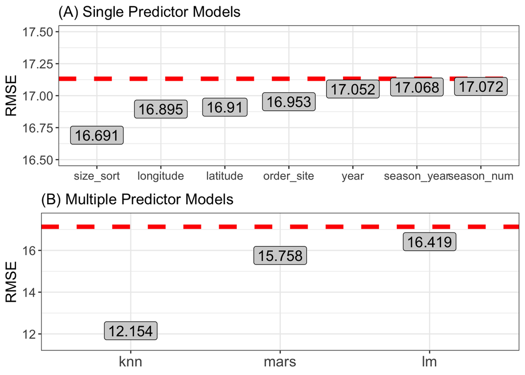

```r
Multipred_df_ordered <- Multipred_df %>%
  mutate(Model = factor(Model, levels = c("knn","mars","lm"))) %>%
  arrange(Model)

Multi_Predictor_RMSE <- Multipred_df_ordered %>% ggplot(aes(x = Model, y=RMSE, label=RMSE)) +
  geom_label(stat='identity',color="black", size=5, face="bold",fill="lightgrey") + ylim(11.5,17.5) + geom_hline(yintercept=base_RMSE,color='red', size=2,linetype="dashed") + theme(title = element_text(size=12), axis.title.y = element_text(size=14),axis.title.x = element_blank(),axis.text.y = element_text(size=12),axis.text.x = element_text(size=14)) + ggtitle("(B) Multiple Predictor Models")
grid.arrange(Single_Predictor_RMSE,Multi_Predictor_RMSE,nrow=2)
```

```r
ggsave(filename = "../../results/Continuous_Outcome_Modeling_results/3.Predictor_RMSE.png",plot = Multi_Predictor_RMSE, width = 5, height = 4)
```

### Multi-predictor models with pre-processing

```r
nzv <- caret::nearZeroVar(data_train, saveMetrics= TRUE)
print(nzv)
```

```
##             freqRatio percentUnique zeroVar   nzv
## total        1.717842    1.58889028   FALSE FALSE
## latitude     1.026403    0.95083198   FALSE FALSE
## longitude    1.026403    0.96334293   FALSE FALSE
## season_year  1.031674    0.71312398   FALSE FALSE
## year         1.007067    0.23770799   FALSE FALSE
## season_num   1.126154    0.05004379   FALSE FALSE
## size_sort    1.001522    0.37532841   FALSE FALSE
## order_site   1.026403    0.96334293   FALSE FALSE
```

None of my predictors have a near-zero variance so I’m not going to remove anthing at this step.

#### Center and Scale

Next, we noticed during our exploratory analysis that it might be useful to center and scale predictors. So let’s do that now. With caret, one can do that by providing the preProc setting inside the train function. Set it to center and scale the data, then run the 3 models from above again.

```r
#write code that repeats the multi-predictor fits from above, but this time applies centering and scaling of variables.
#look at the RMSE for the new fits
fitControl <- trainControl(method="repeatedcv",number=5,repeats=5)
fit2a <- train(total ~ ., data = data_train, method = "lm", trControl = fitControl, preProc = c("center","scale"))
```

[output not shown]

[output cut: 19 more lines]

[output not shown]

```r
fit3a <- train(total ~ ., data = data_train, method = "knn", trControl = fitControl, preProc = c("center","scale"))
fit4a <- train(total ~ ., data = data_train, method = "earth", trControl = fitControl, preProc = c("center","scale"))
print(sprintf('RMSE of lm/knn/mars model %f/%f/%f', fit2a$results$RMSE, min(fit3a$results$RMSE), min(fit4a$results$RMSE) ))
```

```
## [1] "RMSE of lm/knn/mars model 16.464828/13.211649/15.787606"
```

```r
library(knitr)
library(kableExtra)
Model <- c("knn","knn_cs","mars","mars_cs","lm","lm_cs")
RMSE <- c(12.154,13.211,15.758,15.788,16.419,16.465)
Multipred_df_cs <- data.frame(Model,RMSE)
Multipred_df_cs
```

```
##     Model   RMSE
## 1     knn 12.154
## 2  knn_cs 13.211
## 3    mars 15.758
## 4 mars_cs 15.788
## 5      lm 16.419
## 6   lm_cs 16.465
```

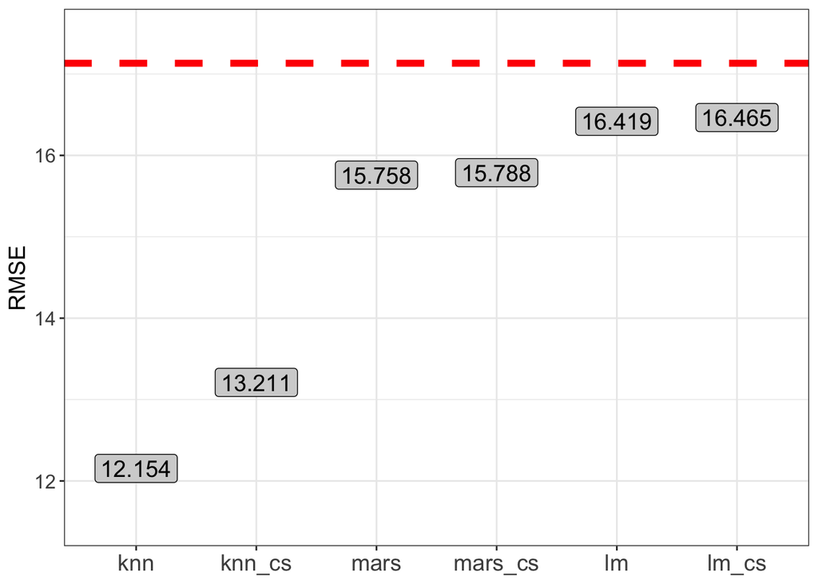

```r
Multipred_df_ordered_cs <- Multipred_df_cs %>%
  mutate(Model = factor(Model, levels = c("knn","knn_cs","mars","mars_cs","lm","lm_cs"))) %>%
  arrange(Model)

Multi_Predictor_RMSE_cs <- Multipred_df_ordered_cs %>% ggplot(aes(x = Model, y=RMSE, label=RMSE)) +
  geom_label(stat='identity',color="black", size=5, face="bold",fill="lightgrey") + ylim(11.5,17.5) + geom_hline(yintercept=base_RMSE,color='red', size=2,linetype="dashed") + theme(title = element_text(size=12), axis.title.y = element_text(size=14),axis.title.x = element_blank(),axis.text.y = element_text(size=12),axis.text.x = element_text(size=14))
Multi_Predictor_RMSE_cs
```

```r
#grid.arrange(Single_Predictor_RMSE,Multi_Predictor_RMSE,nrow=2)
ggsave(filename = "../../results/Continuous_Outcome_Modeling_results/4.Multi_Predictor_RMSE_cs.png",plot = Multi_Predictor_RMSE_cs, width = 5, height = 4)
```

### Model Uncertainty

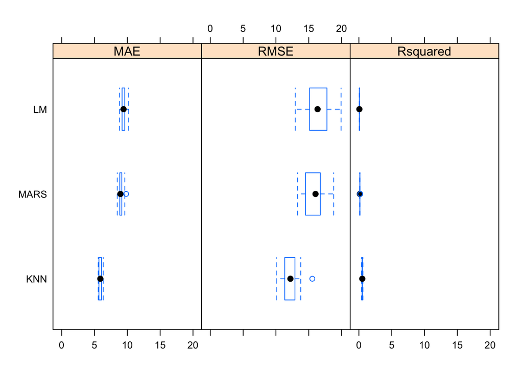

```r
#Use the `resamples` function in caret to extract uncertainty from the 3 models fit to the data  that doesn't have predictor pre-processing, then plot it
resamps <- caret::resamples(list(LM = fit2, KNN = fit3, MARS = fit4))
bwplot(resamps, layout = c(3, 1))
```

```r
#ggsave(filename = "../../results/Continuous_Outcome_Modeling_results/5.Model_Uncertainty.png",plot = bwplot(resamps, layout = c(3, 1)), width = 5, height = 4)
```

### Residual plots

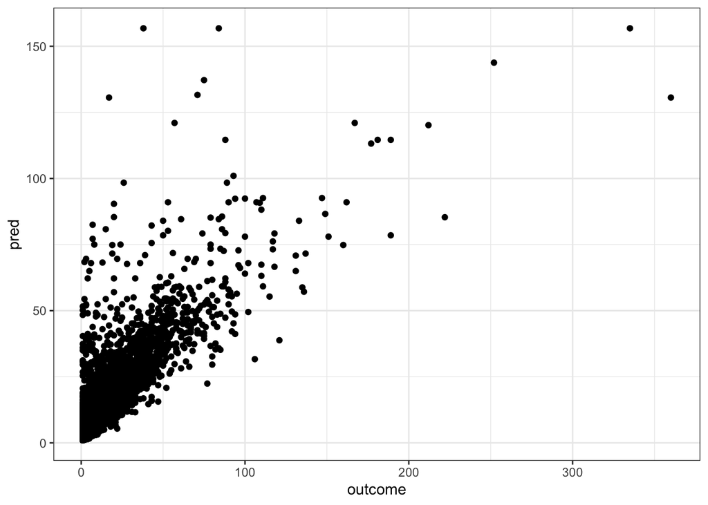

```r
#Write code to get model predictions for the outcome on the training data, and plot it as function of actual outcome values.
#also compute residuals (the difference between prediction and actual outcome) and plot that
pred <- predict(fit3,data_train)
outcome <- data_train$total
resid <- outcome - pred
df_residual <- data.frame(outcome,pred)
#plot(outcome,pred,xlim = c(0,270),ylim=c(0,250))

df_residual %>% ggplot(aes(x=outcome,y=pred)) + geom_point()
```

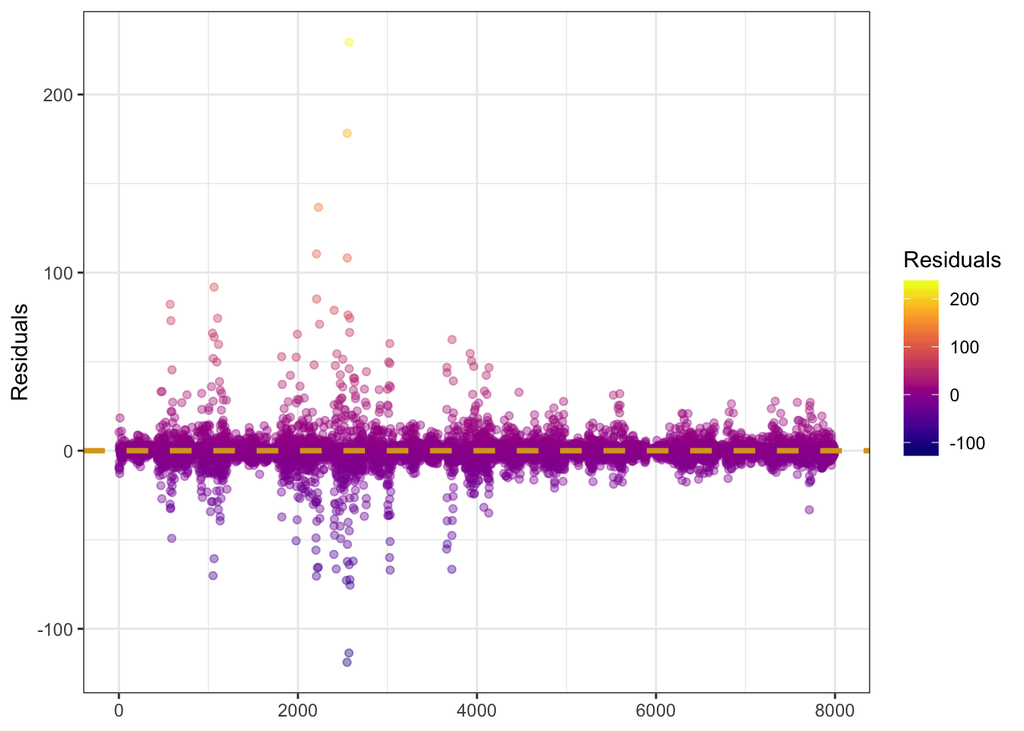

```r
myPaletteresid <- colorRampPalette(viridis_pal(begin = 0, end = 1,option = "plasma")(8),)
title <- "Residuals"
residual_colours <- scale_colour_gradientn(title,colours = myPaletteresid(50))

#skim(resid)
Index <- c(1:7993)
residual_index <- data.frame(Index,resid)
residuals_plot <- residual_index %>% ggplot(aes(x=Index,y=resid,col=resid)) + geom_point(alpha=0.4) + residual_colours + theme(axis.title.x = element_blank()) + ylab("Residuals") + geom_hline(yintercept = 0,color='goldenrod', size=1.25,linetype="dashed")
residuals_plot
```

```r
ggsave(filename = "../../results/Continuous_Outcome_Modeling_results/5.Residuals.png",plot = residuals_plot, width = 5, height = 4)
#plot(resid)
```

## Final model evaluation

### Null Model

```r
outcome = data_test$total
Nobs=nrow(data_test)
base_RMSE <- sqrt(sum((outcome-mean(outcome))^2)/Nobs)
print(sprintf('RMSE of baseline model is %f',base_RMSE))
```

```
## [1] "RMSE of baseline model is 18.028630"
```

```r
#Write code that computes model predictions and for test data, then compute SSR and RMSE.
pred <- predict(fit3,data_test)
outcome <- data_test$total
SSR <- sum( (outcome - pred)^2)
RMSE = sqrt(SSR/length(outcome))
print(RMSE)
```

```
## [1] 11.72762
```

```r
Data <- c("Null_train","fit3_train","Null_test","fit3_test")
RMSE <- c(17.132,12.154,18.029,11.728)
Final_Results <- data.frame(Data,RMSE)
Final_Results
```

```
##         Data   RMSE
## 1 Null_train 17.132
## 2 fit3_train 12.154
## 3  Null_test 18.029
## 4  fit3_test 11.728
```

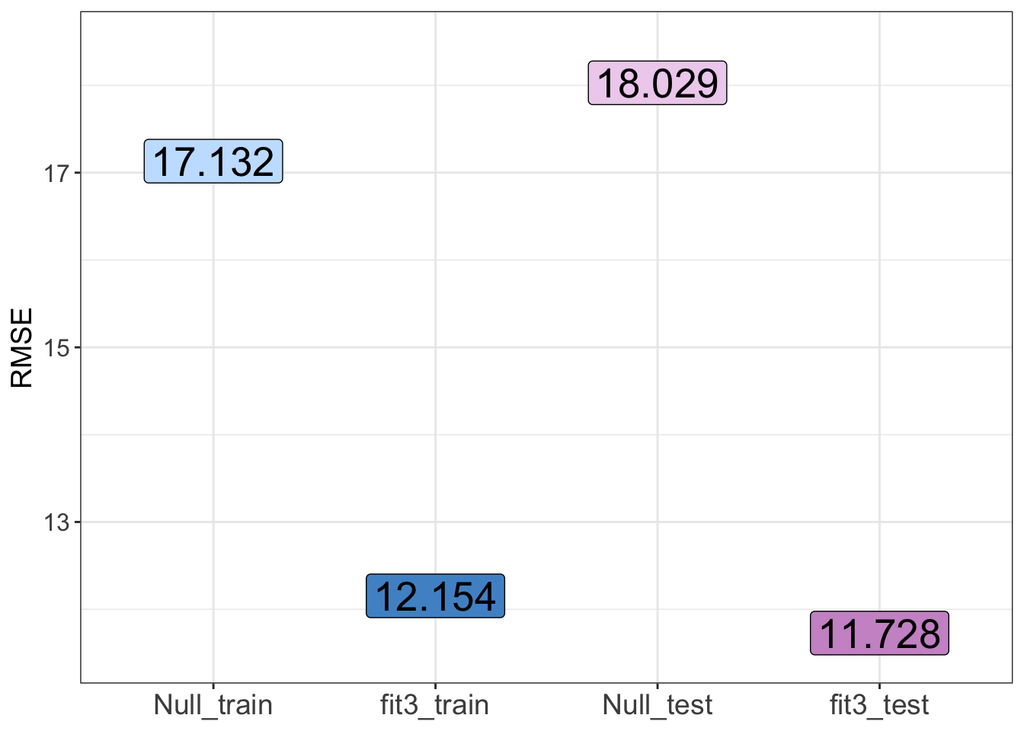

```r
Final_Results_ordered <- Final_Results %>%
  mutate(Data = factor(Data, levels = c("Null_train","fit3_train","Null_test","fit3_test"))) %>%
  arrange(Data)

Final_Results_ordered_plot <- Final_Results_ordered %>% ggplot(aes(x = Data, y=RMSE, label=RMSE)) +
  geom_label(stat='identity',fill=RMSE_colors, size=7, face="bold") + ylim(11.5,18.5) + theme(title = element_text(size=12), axis.title.y = element_text(size=14),axis.title.x = element_blank(),axis.text.y = element_text(size=12),axis.text.x = element_text(size=14))
Final_Results_ordered_plot
```

```r
ggsave(filename = "../../results/Continuous_Outcome_Modeling_results/6.final_results_RMSE.png",plot = Final_Results_ordered_plot, width = 5, height = 4)
```